# 1. for문 기초 다지기

## 학생 줄 세우기 문제

- A, B, C, D, E 다섯 명의 학생들에게 도시락을 나눠주려고 한다.
- 다섯 명의 학생들이 도시락을 받기 위해 순서대로 줄을 서려면 총 몇 가지의 경우의 수가 나올까?
- 이런 경우 팩토리얼 함수를 사용하면 쉽게 해결된다. 팩토리얼(Factorial)은 1부터 n까지 숫자의 곱을 의미한다.
- 팩토리얼은 기호로 !를 사용한다. 예로 5!은 1×2×3×4×5로 계산되어 120이 된다.

[figure not shown]

```python
5*4*3*2*1
```

```
120
```

#### 1. A~E 친구들이 줄을 설 수 있는 경우의 수를 계산하기 위해 필요한 변수를 선언하기

- 팩토리얼을 저장할 변수 fact의 초기 값을 1로 설정 해야 함.
- 초기 값을 0으로 하면 0과의 모든 곱셈이 0이 되기 때문.

```python
fact = 1
friends_num = 5
```

#### 2. for문을 활용해 i가 1부터 5까지 순서대로 커지며 fact에 곱하기

- 끝값을 ‘입력한값+1’로 해야 입력한 값까지 곱셈이 됨

```python
for i in range(1, friends_num+1, 1):
    fact = fact * i

print("A, B, C, D, E 학생들을 순서대로 세우는 경우의 수:", fact)
```

```
A, B, C, D, E 학생들을 순서대로 세우는 경우의 수: 120
```

#### ▶ 50까지의 숫자 중 짝수만 출력하기

```
0 2 4 6 8 10 12 14 16 18 20 22 24 26 28 30 32 34 36 38 40 42 44 46 48 50
```

**(접기/펼치기)**

1.

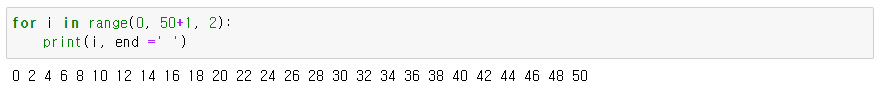

2.

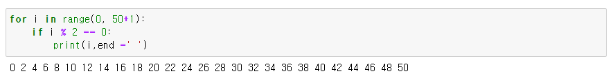

#### ▶구구단 2단 출력하기

```python
for i in range(1,10): # 1,2,3,4,5,6,7,8,9
    print( 2, "x", i , "=", 2*i)
    #print()
```

```
2 x 1 = 2
2 x 2 = 4
2 x 3 = 6
2 x 4 = 8
2 x 5 = 10
2 x 6 = 12
2 x 7 = 14
2 x 8 = 16
2 x 9 = 18
```

**(접기/펼치기)**

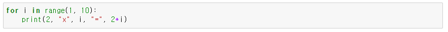

#### ▶10부터 1까지 거꾸로 출력하는 코드

- range의 범위와 증가값을 어떻게 주느냐의 문제

```
10
9
8
7
6
5
4
3
2
1
```

**(접기/펼치기)**

# 2. for문 활용하기

for문의 기본을 익혔으니, 이제 for문을 활용한 다양한 프로그램 작성에 도전해보기

### 1) for문을 활용하여 합계 구하기

#### → for 문을 배우기 전 합계를 구하는 방법

- 10까지의 합계는 단순히 더하기 연산자( + )를 사용하여 간단하게 작성 가능
- 10까지는 이런 방식이 쉽지만, 1000까지 하기에는 매우 힘듦

```python
num_sum = 1+2+3+4+5+6+7+8+9+10
print("1부터 10까지 합계 :", num_sum)
```

```
1부터 10까지 합계 : 55
```

#### → for문을 활용한 반복적인 덧셈

```python
for i in range(1, 11, 1) :
    hap = hap + i # hap 값에 i 값을 더해 줌

print("1에서 10까지의 합 : ", hap)
```

```
---------------------------------------------------------------------------
NameError                                 Traceback (most recent call last)
Input In [1], in <cell line: 1>()
      1 for i in range(1, 11, 1) :
----> 2     hap = hap + i # hap 값에 i 값을 더해 줌
      4 print("1에서 10까지의 합 : ", hap)

NameError: name 'hap' is not defined
```

#### 오류가 발행한 이유

- 변수 hap 선언하지 않았기 때문
- 즉, hap 어떤 값이 있어야만 다시 hap 자기 자신에 누적할 수 있음

[figure not shown]

### 수정된 코드!

- hap에 0이 들어가 있기 때문에 정상적으로 코드가 작동 됨
- 변수를 사용하기 전에 선언해주고, 초기화 해주는 것은 매우 중요한 습관

```python
hap = 0

for i in range(1, 11, 1) : # 1부터 10까지
    hap = hap + i

print("1에서 10까지의 합 : ", hap)
```

```
1에서 10까지의 합 :  55
```

#### 변수 i와 hap의 값 변화

- 변수 i와 hap의 값은 아래 그림과 같이 변하게 된다
- 이러한 과정이 정해진 횟수만큼 반복된다

[figure not shown]

### 100 까지의숫자 중 5의 배수만 더하는 프로그램

```python
x = range(0, 101, 5)
print(list(x))
```

```
[0, 5, 10, 15, 20, 25, 30, 35, 40, 45, 50, 55, 60, 65, 70, 75, 80, 85, 90, 95, 100]
```

```python
x = 0 +  5 +  10 +  15 +  20 +  25 +  30 +  35 +  40 +  45 +  50 +  55 +  60 +  65 +  70 +  75 +  80 +  85 +  90 +  95 +  100
print(x)
```

```
1050
```

```python
hap = 0

for i in range(0, 101, 5) :
    hap += i

print("답 :", hap)
```

```
답 : 1050
```

### 1000~2000 사이에서 홀수의 합을 구하는 프로그램

```python
hap = 0

for i in range(1001,2001,2):
    hap += i
print("1000~ 2000까지의 홀수 합: " , hap)
```

```
1000~ 2000까지의 홀수 합:  750000
```

**(접기/펼치기)**

### 확인문제 )

[figure not shown]

**(접기/펼치기)**

정답 : (500,1001,2)

### 2) 중첩 for문

- for문 안에 또 for문을 사용할 수도 있음
- 이를 중첩 for문 또는 중복 for문이라 함
- 중첩 for문의 실행 횟수: 바깥 for문 반복 횟수 × 안쪽 for문 반복 횟수

[figure not shown]

- 먼저 바깥 for문의 첫 번째 반복을 실행하고, 안쪽 for문의 반복할 문장들은 2회 반복한다
- 다시 바깥 for문의 두 번째 반복이 실행되고, 안쪽 for문의 반복할 문장들이 2회 반복된다.
- 마지막으로 바깥 for문의 세 번째 반복이 실행되고, 안쪽 for문의 반복할 문장들이 2회 반복된다.
- 그리하여 총 3 x 2 = 6번의 반복이 실행된다.

#### → 중첩 for문의 처리되는 순서

```python
for i in range(3) : # 0 ,1 , 2
        for k in range(2) : # 0 ,1
            print("난생처음은 쉽습니다. ( i값:", i ,", k값:", k," )")
```

```
난생처음은 쉽습니다. ( i값: 0 , k값: 0  )
난생처음은 쉽습니다. ( i값: 0 , k값: 1  )
난생처음은 쉽습니다. ( i값: 1 , k값: 0  )
난생처음은 쉽습니다. ( i값: 1 , k값: 1  )
난생처음은 쉽습니다. ( i값: 2 , k값: 0  )
난생처음은 쉽습니다. ( i값: 2 , k값: 1  )
```

#### 중첩 for문 처리 순서 설명

- 외부 for문 1회: i에 0을 대입
  - 내부 for문 1회: k에 0을 대입한 후에 print() 수행
  - 내부 for문 2회: k에 1을 대입한 후에 print() 수행
- 외부 for문 2회: i에 1을 대입
  - 내부 for문 1회: k에 0을 대입한 후에 print() 수행
  - 내부 for문 2회: k에 1을 대입한 후에 print() 수행
- 외부 for문 3회: i에 2를 대입
  - 내부 for문 1회: k에 0을 대입한 후에 print() 수행
  - 내부 for문 2회: k에 1을 대입한 후에 print() 수행

[figure not shown]

## 확인문제 )

[figure not shown]

**(접기/펼치기)**

정답 :6번

### 중첩 for을 사용하여 별( * )로 직각삼각형 만들기

```python
for i in range(1, 6): #1,2,3,4,5
    for j in range(i):
        print('*', end='')
    print("")
```

[output not shown]

```python
for i in range(1, 6):
    for j in range(i):
        print(i ,"번 반복")
    print("")
```

```
1 번 반복

2 번 반복
2 번 반복

3 번 반복
3 번 반복
3 번 반복

4 번 반복
4 번 반복
4 번 반복
4 번 반복

5 번 반복
5 번 반복
5 번 반복
5 번 반복
5 번 반복
```

### 중첩 for을 사용하여 별( * )로 역삼각형 만들기

**(접기/펼치기)**

[figure not shown]

### ※ 이등변 삼각형 그리기

```python
n = 5

for i in range(n):
    for j in range(n-i):
        print(" ", end="")
    for j in range(2*i+1):
        print("*", end="")
    print()
```

-

```python
for i in range(1, 6):
    for j in range(i):
        print("")
        for f in range(j):
            print('*', end='')
```

```python
for i in range(1, 6):
    print("")
    for j in range(i):
        for f in range(j):
            print('*', end='')
```

### 구구단 계산기 만들기 (2단부터 9단까지)

- 2단~9단까지 중첩 for문을 사용해서 생성
- 바깥 for문은 2부터 9까지 1씩 증가하도록, 안쪽 for문은 1부터 9까지 1씩 증가하도록 생성하여 실행

[figure not shown]

```python
for i in range(1, 10, 1):
    print("5 x", i, "=", 5*i)
```

```
5 x 1 = 5
5 x 2 = 10
5 x 3 = 15
5 x 4 = 20
5 x 5 = 25
5 x 6 = 30
5 x 7 = 35
5 x 8 = 40
5 x 9 = 45
```

```python
for i in range(2,10,1):
    for j in range(1,10,1):
        print( i, "x", j  , " = ", i * j)
    print("")
```

```
2 x 1  =  2
2 x 2  =  4
2 x 3  =  6
2 x 4  =  8
2 x 5  =  10
2 x 6  =  12
2 x 7  =  14
2 x 8  =  16
2 x 9  =  18

3 x 1  =  3
3 x 2  =  6
3 x 3  =  9
3 x 4  =  12
3 x 5  =  15
```

[output cut: 64 more lines]

**(접기/펼치기)**

# 3. while문이란?

- while문은 for문과 용도가 비슷하다. 하지만 사용하는 방법이 약간 다르다.
- while문은 for문 다음으로 활용도가 높은 반복문이다.
- 둘을 비교해보면서 while을 배워보자

### 1) for문과 while문의 비교

- for문: 반복할 횟수를 range()에서 결정한 후에, 그 횟수만큼 반복함
- while문: 반복 횟수를 결정하기 보다는 조건식이 참인 경우에 반복함  
  ※ 조건식이 참인 동안에는 계속 반복하게 된다는 점을 기억해야 됨

[figure not shown]

## for문 vs while문

- “난생처음 ~” 문장을 3번을 반복하는 for문
- “ i ”에 차례대로 0,1,2를 입력하여 3회 반복 진행

```python
for i in range(0, 3, 1) :
    print(i, ": 난생처음 파이썬은 재미있습니다. ^^")
```

```
0 : 난생처음 파이썬은 재미있습니다. ^^
1 : 난생처음 파이썬은 재미있습니다. ^^
2 : 난생처음 파이썬은 재미있습니다. ^^
```

#### for문을 while문으로 변경하기

- while문의 경우, “ i ”를 넣는 문법이 따로 있지 않음.
- 따라서 while문이 시작되기 전에 먼저 “ i ”를 시작값으로 지정하고 진행해야 됨
- 강제로 1을 증가시키는 구문을 추가해야 됨. ( i = i + 1 )

```python
i=0

while (i < 3) :
    print(i, " : 난생처음 파이썬은 재미있습니다. ^^")
    i = i + 1
```

```
0  : 난생처음 파이썬은 재미있습니다. ^^
1  : 난생처음 파이썬은 재미있습니다. ^^
2  : 난생처음 파이썬은 재미있습니다. ^^
```

[figure not shown]

### ▶ while문으로 1부터 10까지 출력하기

```python
i = 1

while (i <= 10) :
    print(i)
    i = i + 1
```

```
1
2
3
4
5
6
7
8
9
10
```

### ▶ while문으로 1부터 10까지 합 구하기

```python
total = 1+2+3+4+5+6+7+8+9+10
print("1에서 10까지의 합: ", total)
```

```
1에서 10까지의 합:  55
```

```python
i = 0
total = 0

while (i <= 10):
    total = total + i
    i = i + 1

print("1에서 10까지의 합:", total)
```

```
1에서 10까지의 합: 55
```

**(접기/펼치기)**

i = 0  
total = 0

while (i <= 10):  
total = total + i  
i = i + 1

print("1에서 10까지의 합:", total)

### ▶ input( )으로 횟수를 입력받아 음표(♪) 출력하기

```python
n = int(input("몇개의 음표를 출력할까요? "))
i = 1

while i <= n:
    print("♪", end="")
    i += 1
```

```
몇개의 음표를 출력할까요? 10
♪♪♪♪♪♪♪♪♪♪
```

**(접기/펼치기)**

n = int(input("몇개의 음표를 출력할까요? "))  
i = 1  
while i <= n:  
print("♪", end="")  
i += 1

### ▶입력받은 문자열이 일치할 때, 종료하기

```python
text = ""                       # 빈 문자열로 초기화
while text != "stop":          # 변수가 "stop"이 아닐 동안 반복
    text = input("문자열을 입력하세요: ")
print("프로그램을 종료합니다.") #  "stop"을 입력되면 반복이 종료
```

```
문자열을 입력하세요: dd
문자열을 입력하세요: dd
문자열을 입력하세요: dd
문자열을 입력하세요: dd
문자열을 입력하세요: dd
문자열을 입력하세요: dd
문자열을 입력하세요: dd
문자열을 입력하세요: dd
문자열을 입력하세요: stop
프로그램을 종료합니다.
```

### 확인문제 )

[figure not shown]

**(접기/펼치기)**

정답 : 5번

## while문의 무한 반복

### 무한 루프(무한 반복)

- 무한 루프란 무한히 반복됨을 의미
- 반복문을 빠져나올 조건이 없어 무한히 while문 내부를 반복함
- ‘while 조건식 : ‘ 의 조건식을 True로 지정하면 무한 루프로 지정됨

[figure not shown]

### 무한 반복하는 간단한 while문

- while 문은 조건이 참(True)일 때, 반복하는 반복문
- 따라서 조건식 대신 True를 지정하면 무한히 반복하는 무한 루프가 만들어진다.
- ~무한 반복 중지하는 방법 : [Ctrl] + [C]~
- 무한 반복 중지하는 방법 : [ i ] [ i ]

#### 글자 ‘ㅎ’ 무한 출력하기

```python
while True :
        print("ㅎ", end = " ")
```

### 실행중인 상태 확인하는 법

- 셀(cell)의 상태 확인
- 인터넷 창 아이콘 확인
  - 실행중인 상태일 때는 모래시계모양의 아이콘
  - 실행중이지 않은 상태일 때는 책모양의 아이콘

[figure not shown]

### 실행 중지 시키는 법

[figure not shown]

### 무한 루프를 이용해 입력한 두 숫자의 합계를 반복해서 계산하는 프로그램

- 사용자가 프로그램을 중단하기위한 버튼을 누르기 전까지는 계속 두 숫자를 입력받고 두 수를 더한 결과를 출력함

```python
hap, num1, num2 = 0, 0, 0

while True :
    num1 = int(input("숫자1 ==> "))
    num2 = int(input("숫자2 ==> "))
    hap = num1 + num2
    print(num1, "+", num2, "=", hap)
    print()
```

```
숫자1 ==> 1
숫자2 ==> 2
1 + 2 = 3

숫자1 ==> 3
숫자2 ==> 4
3 + 4 = 7

숫자1 ==> 5
숫자2 ==> 6
5 + 6 = 11

숫자1 ==> 7
숫자2 ==>
```

```
---------------------------------------------------------------------------
ValueError                                Traceback (most recent call last)
Input In [3], in <cell line: 4>()
      3 while True :
      4     num1 = int(input("숫자1 ==> "))
----> 5     num2 = int(input("숫자2 ==> "))
      6     hap = num1 + num2
      7     print(num1, "+", num2, "=", hap)

ValueError: invalid literal for int() with base 10: ''
```

### 실생활에서의 while문

- 카페 알바생이 손님의 주문을 받는 상황
- while문을 사용하여 무한히 표현할 수 있다.
- ( break문을 사용하면 셀을 강제종료시키지 않아도 무한루프에서 탈출할 수 있다)

```python
while True:
    order = input("어떤 음료를 주문하시겠어요? ")
    print(order, "완성되었습니다.")
    print()
```

```
어떤 음료를 주문하시겠어요? 아메리카노
아메리카노 완성되었습니다.

어떤 음료를 주문하시겠어요? 라떼
라떼 완성되었습니다.

어떤 음료를 주문하시겠어요? 아이스티
아이스티 완성되었습니다.
```

[output not shown]

### ※ for문과 while문

- for문은 주로 일정한 범위 내에서(구하고자 하는 정확한 조건이 있는 경우) 반복을 수행할 때 주로 사용된다.
- while문은 조건이 참(True)인 동안 반복하여 코드를 실행하며, 특정 조건이 충족될 때까지(혹은 조건을 정확히 모를 경우) 주로 사용된다.
- 예를 들어, 게임에서 사용자의 입력을 계속해서 받아 처리하거나, 데이터베이스에서 검색 결과가 존재하는 동안 처리를 반복하는 등의 상황, 혹은 파일의 끝까지 데이터를 읽어야 하는 경우에는 파일의 크기를 미리 알 수 없기 때문에 while문을 사용하여 파일의 끝까지 데이터를 읽는 처리를 반복 수행할 수 있다,
- 따라서, 문제의 성격과 상황에 따라 while문과 for문 중에서 적절한 것을 선택하여 사용해야 한다.

# 3. break문과 continue문

- 반복문을 강제로 탈출하는 경우와 반복문의 처음으로 돌아가게 만드는 경우를 살펴본다

### 반복문을 탈출하는 break문

- for문은 range()함수에서 지정한 범위에서 벗어나면 종료된다.
- while문은 조건식이 False가 되면 종료된다.
- 무한 반복의 경우 정지버튼을 눌러야지 무한히 반복되는 루프를 종료시킬 수 있다.
- 이 때, break문을 사용하면 강제로 종료시키지 않고도 논리적으로 빠져나갈 수 있게 해준다.

[figure not shown]

- 반복문안에서 break문을 만나게 되면 무조건 반복문에서 탈출하게 된다.
- 간단한 코드로 확인할 수 있다.

#### 1부터 1000까지의 숫자를 1씩 증가시키면서 반복문을 만들었지만, 실행하자마자 break문 만나 1회만 반복되고 종료되었다.

- 코드 중 break문을 만나면 즉시 반복문이 종료되는 것을 알 수 있다.

```python
for i in range(1, 1001, 1) :
    print("반복문을", i, "회 실행합니다.")
    break
```

```
반복문을 1 회 실행합니다.
```

## 반복문을 탈출하는 break문

- break문을 사용하여 첫 번째 숫자(num1)에 0을 입력하면 반복문을 빠져나가도록 만들 수 있다.
- 실제 break문은 무한 루프 안에서 if문과 함께 사용되는 경우가 많다.
- 무한루프를 돌다가 특정 조건이 되면 반복문을 빠져나가도록 설정하는 것

```python
hap, num1, num2 = 0, 0, 0  # 변수를 0으로 초기화

while True :
    num1 = int(input("숫자1 ==> "))
    if num1 == 0 :   # 만약 num1(숫자1)이 0이면 break문을 이용하여 while 반복문을 종료
        break
    num2 = int(input("숫자2 ==> "))
    hap = num1 + num2
    print(num1, "+", num2, "=", hap)
    print()

print("0을 입력해서 계산을 종료합니다.") # while문이 종료되면 출력
```

```
숫자1 ==> 1
숫자2 ==> 2
1 + 2 = 3

숫자1 ==> 3
숫자2 ==> 4
3 + 4 = 7

숫자1 ==> 5
숫자2 ==> 6
5 + 6 = 11

숫자1 ==> 7
숫자2 ==> 8
7 + 8 = 15

숫자1 ==> 0
0을 입력해서 계산을 종료합니다.
```

**(접기/펼치기)**

```
hap = num1 + num2
print(num1, "+", num2, "=", hap)
print()
```

print("0을 입력해서 계산을 종료합니다.") # while문이 종료되면 출력

### "영업종료"가 입력되면 카페 영업이 끝나는 프로그램

- 무한루프 while문을 만들어 input() 함수를 사용하여 사용자로부터 음료를 무한히 주문받는다.
- if문을 사용하여 order 변수가 "영업종료"가 들어올 경우, "영업 종료합니다."를 출력하여 무한루프를 종료시킨다.

```
어떤 음료를 주문하시겠어요? 아아
아아 완성되었습니다.

어떤 음료를 주문하시겠어요? 아아
아아 완성되었습니다.

어떤 음료를 주문하시겠어요? 아이스티
아이스티 완성되었습니다.

어떤 음료를 주문하시겠어요? 영업종료
영업 종료합니다.
```

**(접기/펼치기)**

```
if order == "영업종료":
    print("영업 종료합니다.")
    break

print(order, "완성되었습니다.")
print()
```

## 12시가 되면 접수를 마감하는 프로그램

```python
while True:
    order = int(input("시간을 입력해주세요 "))
    if order >= 12  :
        print("접수를 마감합니다.")
        break
    print("접수되었습니다.")
    print()
```

```
시간을 입력해주세요 1
접수되었습니다.

시간을 입력해주세요 2
접수되었습니다.

시간을 입력해주세요 12
접수를 마감합니다.
```

**(접기/펼치기)**

## 처음으로 돌아가는 continue문

- break문이 반복문을 탈출(종료)하도록 한다면, continue문은 남은 부분을 모두 건너뛰고, 반복문의 처음으로 돌아가게 한다.

[figure not shown]

### 숫자 1~100을 더하되 4의 배수는 더하지 않는 프로그램

- 4의 배수를 아는 방법은 4로 나눈 나머지 값이 0인지 확인하면 된다.
- 1 + 2 + 3 + 5 + 6 + 7 + 9 + … 와 같이 4의 배수를 건너뛰고 합계를 구하기

```python
i, hap = 0, 0

for i in range(1,101,1) :
    if i % 4 == 0 :
        continue
    hap += i

print("1~100의 합계(4의 배수 제외) : ", hap)
```

```
1~100의 합계(4의 배수 제외) :  3750
```

[figure not shown]

# 주사위 3개를 동시에 던져 동일한 숫자 나오기

- 주사위 3개를 동시에 던져 모두 동일한 숫자가 나와야만 반복문을 탈출할 수 있는 게임을 만들어보자
- 몇 번을 던져야 3개의 주사위에서 동일한 숫자가 나올까?
- 몇 번을 던져야 3개의 주사위가 동시에 같은 수가 나오는지 알 수가 없으므로, 일단은 무한 루프로 주사위를 던진다.
- 그리고 무한 루프 안에서 조건문으로 3개의 주사위가 같은 숫자면 무한 루프를 빠져나가도록 한다.

[figure not shown]

- 무작위로 주사위를 던지기 위해 random을 임포트한 후, 주사위를 던진 횟수를 저장할 변수와 주사위 3개도 선언하기

```python
import random

count, dice1, dice2, dice3 = 0, 0, 0, 0
```

- 3개의 주사위 던지기를 무한 반복하면서 주사위 던진 횟수를 1씩 증가시키기
- 3개의 주사위 숫자가 같다면 break문으로 무한 반복을 탈출하기

```python
while True :
    count += 1
    dice1 = random.randint(1,6)
    dice2 = random.randint(1,6)
    dice3 = random.randint(1,6)

    if (dice1 == dice2) and (dice2 == dice3) :
        break
```

- 주사위 3개에서 동시에 나온 숫자와 횟수를 출력하기

```python
print("3개 주사위는 모두", dice1, "입니다.")
print("같은 숫자가 나오기까지", count, "번 던졌습니다.")
```

```
3개 주사위는 모두 2 입니다.
같은 숫자가 나오기까지 42 번 던졌습니다.
```

## 컴퓨터와 인간의 숫자 맞히기 대결

- 컴퓨터가 1~5까지 숫자 중 한 가지를 생각하면, 사람이 그 숫자를 맞히는 게임입니다. 단 10번 안에는 맞혀야 합니다.
- 이세돌 9단과 알파고의 바둑 대결만큼은 아니지만, 컴퓨터와 인간의 대결이라고 볼 수 있습니다.
- 숫자를 맞힌다면 break문으로 반복문을 빠져 나가고, 맞히지 못하면 continue문으로 다시 반복문의 처음 부분으로 돌아가도록 구현합니다

[figure not shown]

```python
import random

computer, user = 0, 0

for i in range(1, 11, 1) :
    computer = random.randint(1, 5)
    print ("게임", i, "회:", end='')
    user = int(input("컴퓨터가 생각한 숫자는 ? "))
    if computer == user :
        print(" 맞혔네요. 축하합니다 !! ")
        break
    else :
        print(" 아까워요. 답은(", computer, ") 였는데요. 다시 해보세요.ㅠ")
        print()
        continue

print("\n게임을 마칩니다.")
```

```
게임 1 회:컴퓨터가 생각한 숫자는 ? 1
 아까워요. 답은( 4 ) 였는데요. 다시 해보세요.ㅠ

게임 2 회:컴퓨터가 생각한 숫자는 ? 1
 아까워요. 답은( 3 ) 였는데요. 다시 해보세요.ㅠ

게임 3 회:컴퓨터가 생각한 숫자는 ? 1
 맞혔네요. 축하합니다 !!

게임을 마칩니다.
```

# 요약

1. 반복문은 프로그램 안의 특정 부분을 원하는 횟수만큼 반복하게 만든다.
2. for문과 while문은 상당히 친구 같은 사이라 용도는 비슷하면서도 차이점이 있다.
3. 무한루프란 무한 반복을 의미하며 반복문을 빠져나올 조건 없이 무한히 while문의 내부를 반복하는 것을 의미한다.
4. 반복문 안에서 break문을 만나면 무조건 반복문을 빠져나온다.
5. countinue문은 남은 부분을 모두 건너 뛰고, 반복문의 처음으로 돌아간다.